# Genomics Project Report

### Gene Lengths Visualization

After creating the GRanges objects, we calculated the length of each gene using the width and sum functions on the GRangesList. Since some genes are much longer than others, a standard barplot would be difficult to read. We used the `gap.barplot` function from the plotrix library, which allows us to create a barplot with a gap in the y-axis to accommodate extremely long genes while still showing variation among shorter genes.

```
## ylim -74801 48059
```

[figure not shown]

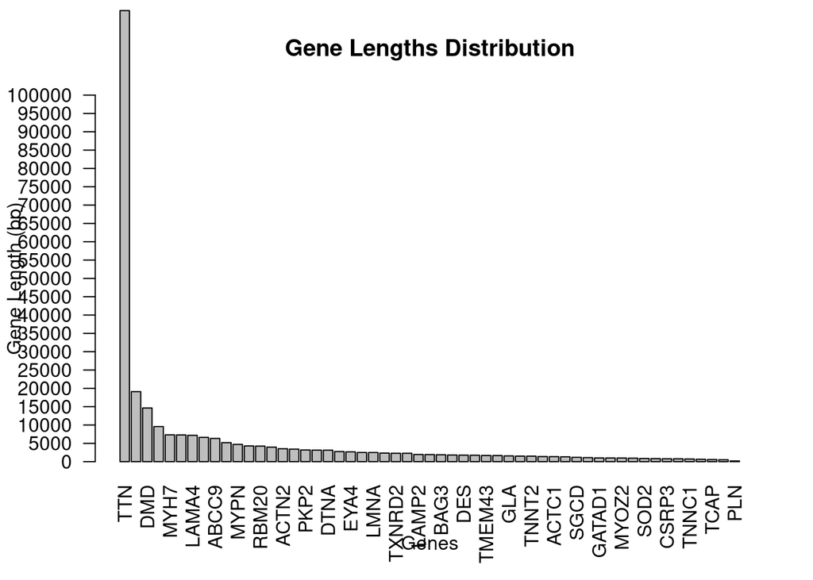

### Loading the Mapped Reads

We used the output from the mapping step (the BAM file) to inspect the coverage of all mapped positions across our panel genes. The Rsamtools library provides the necessary functions to read and process this alignment data into GRanges objects for further analysis.

First, we used the *BamFile* function to create a reference to our BAM file and its index, which allowed us to access the alignment data efficiently without loading the entire file into memory. Then, to extract only our specific gene regions from the BED-data, we used the *ScanBamParam* function with GRanges objects to set the parameters for selection. Finally, we applied the *pileup* function to retrieve the coverage information for these regions, which returned the actual read counts at each position within our genes for downstream analysis. Here the pileup data for **TTN** gene.

```
##   seqnames       pos strand nucleotide count              which_label
## 1     chr2 178526992      +          G   219 chr2:178526992-178527327
## 2     chr2 178526992      -          G    68 chr2:178526992-178527327
## 3     chr2 178526993      +          A     2 chr2:178526992-178527327
## 4     chr2 178526993      +          T   215 chr2:178526992-178527327
## 5     chr2 178526993      -          T    68 chr2:178526992-178527327
## 6     chr2 178526994      +          A   218 chr2:178526992-178527327
```

### Pileup Processing

Here, we will obtain the pileup data for all our genes and store it in a single object `pileup_list`. This will allow us to calculate the average coverage for each gene and identify positions with low coverage that may require further inspection.

```
##   seqnames       pos strand nucleotide count              which_label
## 1     chr2 178526992      +          G   219 chr2:178526992-178527327
## 2     chr2 178526992      -          G    68 chr2:178526992-178527327
## 3     chr2 178526993      +          A     2 chr2:178526992-178527327
## 4     chr2 178526993      +          T   215 chr2:178526992-178527327
## 5     chr2 178526993      -          T    68 chr2:178526992-178527327
## 6     chr2 178526994      +          A   218 chr2:178526992-178527327
```

This table shows the raw sequencing data for every position in our genes. Each row represents one nucleotide position, telling us which chromosome it’s on, the exact location, which DNA strand the read came from, what base (A, T, G, or C) was detected, and how many times that base was seen. The last column just labels which gene the position belongs to. This data helps us see how well each region was covered during sequencing and spot any positions that might need a closer look.

### Coverage calculation and reporting

In this assignment, we calculated the per-position coverage for each gene using the *aggregate* function, which sums the count values for each unique position across all reads. For every gene, we then determined: the number of bases sequenced, the average coverage, the number of low-coverage positions (below 30), and the percentage of low-coverage positions. These four values were stored in a new data frame along with the gene name, and the final results were ordered by the percentage of low-coverage positions in descending order for easy interpretation.

```
## [1] "All genes processed:"
```

```
##      Gene NumBases AvgCoverage LowCovPos LowCovPerc
## 1   ABCC9     6339   247.83168         0  0.0000000
## 2   ACTC1     1375   189.40800        57  4.1454545
## 3   ACTN2     3527   182.87780         0  0.0000000
## 4  ANKRD1     1322   229.81846         0  0.0000000
## 5    BAG3     1892   205.08932         0  0.0000000
## 6   CALR3     1511   241.36334         0  0.0000000
## 7    CAV3      536   192.04478         0  0.0000000
## 8   CRYAB      650   151.92923         1  0.1538462
## 9   CSRP3      785   228.70955         0  0.0000000
## 10    DES     1774   118.87768       260 14.6561443
## 11    DMD    14643   246.64864         0  0.0000000
## 12   DSC2     3427   236.54771       110  3.2098045
## 13   DSG2     3959   237.98106        86  2.1722657
## 14    DSP     9577   235.54704         6  0.0626501
```

[output cut: 41 more lines]

Coverage analysis across the 55 cardiomyopathy genes shows that the majority **(40 genes)** have excellent sequencing coverage with **0%** low coverage positions. However, several genes show concerning coverage gaps. JPH2 has the poorest coverage with **(30.7%)** of the gene falling below acceptable thresholds, followed by GATAD1 **(21.3%)**, TPM1 **(16.8%)**, and PRKAG2 **(16.3%)**. Other genes with significant coverage issues include DES **(14.7%)**, JUP **(11.2%)**, and MYBPC3 **(10.5%)**. These genes with >10% low coverage warrant careful interpretation as potential variants in these poorly covered regions may be missed. In contrast, important large genes like TTN maintained excellent coverage throughout, increasing confidence in variant detection.

## Variant Calling

Variant calling was performed to identify single nucleotide variants (SNVs) and small insertions/deletions (indels) from the aligned reads. We interest in a SNVs variants only, and using the default sittings in the tool.

**Variant caller used: `Call variants with LoFreq`**

### Raw Variant Output (VCF File)

```
##   CHROM      POS ID REF ALT QUAL FILTER                                 INFO
## 1  chr1 27325641  .   A   G  144   PASS     DP=16;AF=0.3125;SB=0;DP4=9,2,5,0
## 2  chr1 71625045  .   C   T  147   PASS   DP=14;AF=0.428571;SB=0;DP4=8,0,6,0
## 3  chr1 71625166  .   C   A  517   PASS DP=31;AF=0.548387;SB=0;DP4=14,0,17,0
## 4  chr1 71625235  .   G   T  729   PASS DP=46;AF=0.543478;SB=1;DP4=14,7,18,7
## 5  chr1 77774432  .   T   C  425   PASS       DP=20;AF=0.65;SB=0;DP4=4,3,6,7
## 6  chr1 77917782  .   G   A 5119   PASS   DP=332;AF=0.5;SB=4;DP4=95,71,85,81
```

## Variant Filtering (VCF File Processing)

To minimize false positive calls, variants were filtered using established quality metrics, including read depth, variant quality score, and allele frequency. The filtering workflow began by extracting allele frequency (AF) information from the VCF file. This AF data was subsequently incorporated as an additional column following the creation of GRanges objects.

Variants were subsequently filtered to retain only those with an allele frequency of ≥30%.

```
## GRanges object with 1108 ranges and 1 metadata column:
##          seqnames    ranges strand |        AF
##             <Rle> <IRanges>  <Rle> | <numeric>
##      [1]     chr1  27325641      * |  0.312500
##      [2]     chr1  71625045      * |  0.428571
##      [3]     chr1  71625166      * |  0.548387
##      [4]     chr1  71625235      * |  0.543478
##      [5]     chr1  77774432      * |  0.650000
##      ...      ...       ...    ... .       ...
##   [1104]     chrX  76653828      * |  0.538462
##   [1105]     chrX 114758092      * |  1.000000
##   [1106]     chrX 144264053      * |  0.733333
##   [1107]     chrX 154412069      * |  1.000000
##   [1108]     chrX 154421359      * |  0.457143
##   -------
##   seqinfo: 26 sequences from an unspecified genome; no seqlengths
```

To identify all variants falling within exonic regions, an overlap analysis was performed using the `findOverlaps` function. The resulting output contains two columns: `queryHits` and `subjectHits.` The `queryHits` column indicates the rows from the VCF data that lie within an exon, representing the variants of interest. The `subjectHits` column corresponds not to individual exons but to genes, meaning a `subjectHits` value of 1 refers to a hit within any exon of the first gene.

```
## DataFrame with 129 rows and 2 columns
##     queryHits subjectHits
##     <integer>   <integer>
## 1          21          25
## 2          23          25
## 3          24          25
## 4          35          51
## 5          36          51
## ...       ...         ...
## 125      1085          11
## 126      1090          11
## 127      1097          11
## 128      1098          11
## 129      1107          45
```

After obtaining the row numbers of variants to retain, the filtered VCF file was reconstructed. This was achieved by reading the original VCF file with the readLines function. The header lines and variant rows were extracted separately, then recombined to generate the final filtered VCF file.

## Variant Visualization

### Allele frequency distribution

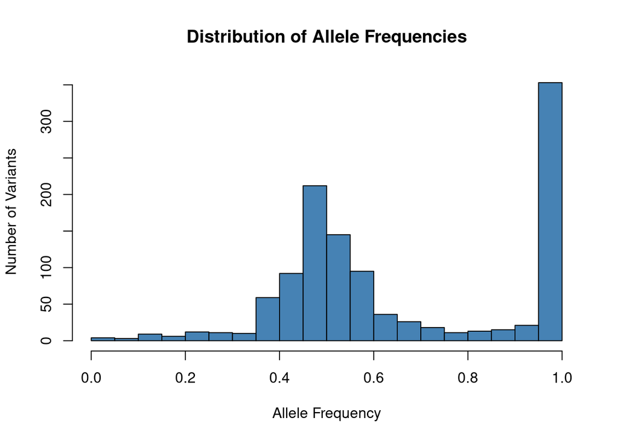

The two peaks in the allele frequency histogram correspond to the two possible zygosity states in a diploid genome:

- **50%**: Heterozygous variants, where one copy carries the alternative allele and the other carries the reference allele
- **100%**: Homozygous variants, where both copies carry the alternative allele

### Variants per gene

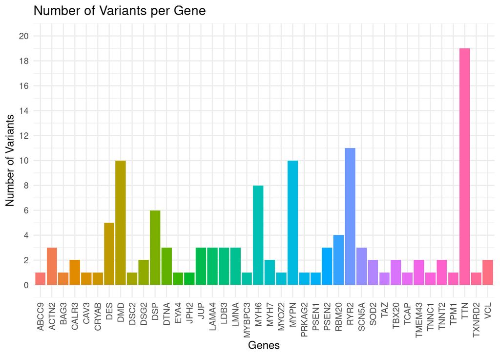

Looking at the distribution of variants across genes, **TTN** had the highest number with 19 variants, followed by **RYR2** with 11. **MYPN** and **DMD** each had 10 variants, while **MYH6** had 8. A few other genes like **DSP** (6) and **DES** (5) also showed moderate variant counts. The rest of the genes had smaller numbers, mostly between 1 and 3 variants.

What’s interesting is that most of the genes with the highest variant counts are actually known to be involved in heart disease. So even though the variants are spread across many genes, the ones with the most hits tend to be those with known roles in cardiac function. This is not surprising, as our samples were obtained from patients with cardiomyopathy, so finding more variants in heart-disease-associated genes is expected.

## Variant Annotation

The filtered VCF file was uploaded to Galaxy for the subsequent annotation step to identify and characterize the genetic differences.

### SnpEff and SnpSift

Following variant calling with `LoFreq`, we performed three sequential annotation steps to add functional, clinical, and population-level information to our filtered VCF file.

**SnpEff – Functional Annotation**

We used `SnpEff` with the GRCh38.p14 genome reference to annotate our filtered VCF file. This tool adds functional predictions for each variant, including impact severity (HIGH, MODERATE, LOW, MODIFIER), gene names, transcript biotypes, and HGVS nomenclature. All annotation details are stored in the `ANN` field. The output consists of an annotated VCF file and a web-based summary report.

**SnpSift – dbSNP and ClinVar Annotation**

We ran `SnpSift` to add known variant identifiers and clinical significance data using the `dbSNP` database that includes `ClinVar` information. The `ID` column was populated with ClinVar identifiers, and the `INFO` field was expanded with clinical significance (CLNSIG), disease names (CLNDN), and review status (CLNREVSTAT) for known variants.

**SnpSift – dbNSFP Annotation**

We used `SnpSift` to annotate our VCF with the `dbNSFP` database, a comprehensive collection of over 300GB of integrated annotation sources. This step added population allele frequencies from gnomAD and ExAC, multiple in-silico prediction scores (including SIFT, PolyPhen, REVEL, CADD, and AlphaMissense), conservation metrics, and gene constraint information. The resulting file, `SnpVariants_Step3.vcf`, was used for subsequent filtering and analysis in Galaxy.

**Annotation Summary**